# Association Rules Mining

## Module 1

### Brock Tibert

### October 21st, 2019

## CourseKey

- CourseID to login via our smartphones
- Sound plays over the speaker
- Used to check into class __and labs__

# .text-shadow[Basic Example]

# BU Example

# BU Example Inverted

# A basic slide 1- column slide

- Item 1
- Item 2
- Item 3
  - A nested item
- Another item

- __A bolded item__

- Something _italicized_

- This has text here

> REMEMBER:  `xaringan::infinite_moon_reader()` to help render live and build deck

# An incremental slide

### 1.  Point one

### 2.  Point two

### 3.  Point __three__

Here is some text with a seque slide

Seque red

Seque yellow

- List item on the left
- List item on below that
- incremental item

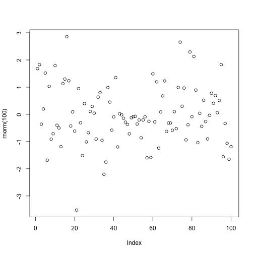

```r
plot(rnorm(100))
```

# Data table 1

| carat | cut | color | clarity |
| --- | --- | --- | --- |
| 0.23 | Ideal | E | SI2 |
| 0.21 | Premium | E | SI1 |
| 0.23 | Good | E | VS1 |
| 0.29 | Premium | I | VS2 |
| 0.31 | Good | J | SI2 |
| 0.24 | Very Good | J | VVS2 |
| 0.24 | Very Good | I | VVS1 |
| 0.26 | Very Good | H | SI1 |
| 0.22 | Fair | E | VS2 |
| 0.23 | Very Good | H | VS1 |

# Datatable 2

|  | Sepal.Length | Sepal.Width | Petal.Length | Petal.Width | Species |
| --- | --- | --- | --- | --- | --- |
| 1 | 5.1 | 3.5 | 1.4 | 0.2 | setosa |
| 2 | 4.9 | 3 | 1.4 | 0.2 | setosa |
| 3 | 4.7 | 3.2 | 1.3 | 0.2 | setosa |
| 4 | 4.6 | 3.1 | 1.5 | 0.2 | setosa |
| 5 | 5 | 3.6 | 1.4 | 0.2 | setosa |
| 6 | 5.4 | 3.9 | 1.7 | 0.4 | setosa |
| 7 | 4.6 | 3.4 | 1.4 | 0.3 | setosa |
| 8 | 5 | 3.4 | 1.5 | 0.2 | setosa |
| 9 | 4.4 | 2.9 | 1.4 | 0.2 | setosa |
| 10 | 4.9 | 3.1 | 1.5 | 0.1 | setosa |

## Here is R code snippet with line and highlight

```r
for (i in j) {
*   print(i)
}
```

## Another example

```r
for (i in j) {
*   print(i)
}
```

1. Item 1
1. Item 2
1. __Item 3__ bolded

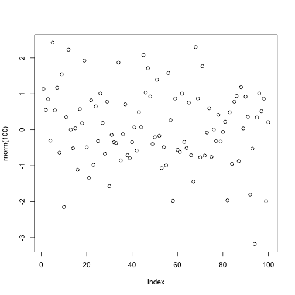

# Slide with Footer

- This is an item
- This is another item.fn[1]
- This is another item

[2] At the end of the slide `.footnote[[1] Text associated with footnote 1.]`

# We can nest pull-* for multiple columns and break up slides

- item 1 col 1
- item 2 col 2

- item1 col 2
- item 2 col 2

- item 1 col 3
- item 2 col 3

`.pull-*` always is half the slide, so we are just dividing up the slide

> The horizontal line is because `--- ` has a space after it, not a `return`

# Help on customization

[Syndey Theme Drives this](https://garthtarr.github.io/sydney_xaringan/#45)

# Break down a function and tutorial

```r
x = sample(
           x = letters,
           size = 10,
           replace = FALSE
           )
```

# Break down a function and tutorial

```r
x = sample(
*          x = letters,
           size = 10,
           replace = FALSE
           )
```

- `x` = the object we are going to sample from.  In this case, the built in `letters` dataset

# Break down a function and tutorial

```r
x = sample(
           x = letters,
*          size = 10,
           replace = FALSE
           )
```

- `size` = how many samples that we want to draw from `x`

# Break down a function and tutorial

```r
x = sample(
           x = letters,
           size = 10,
*          replace = FALSE
           )
```

- `replace` = should the element drawn from `x` be replaced so that can it be selected in another draw?

- Above if `size` was larger than 26, we would have to use `replace=TRUE` to ensure that we have > 0 elements to draw from